# Importing Dataset

### Random Forests Max Depth Limit on RF Reduced Dataset

```python
md_list = [1,2,3,4,5,6,7,8,9,10,11,12,13,14,15]
accuracy_train = []
accuracy_test = []
for md in md_list:
    rf3=RandomForestClassifier(max_depth=md,min_samples_split=5, n_estimators=90)
    # Code here
    rf3.fit(X_train2, y_train2)

    pred=rf3.predict(X_train2)
    accuracy_train.append(metrics.accuracy_score(y_train2, pred))

    pred=rf3.predict(X_test2)
    accuracy_test.append(metrics.accuracy_score(y_test2, pred))
```

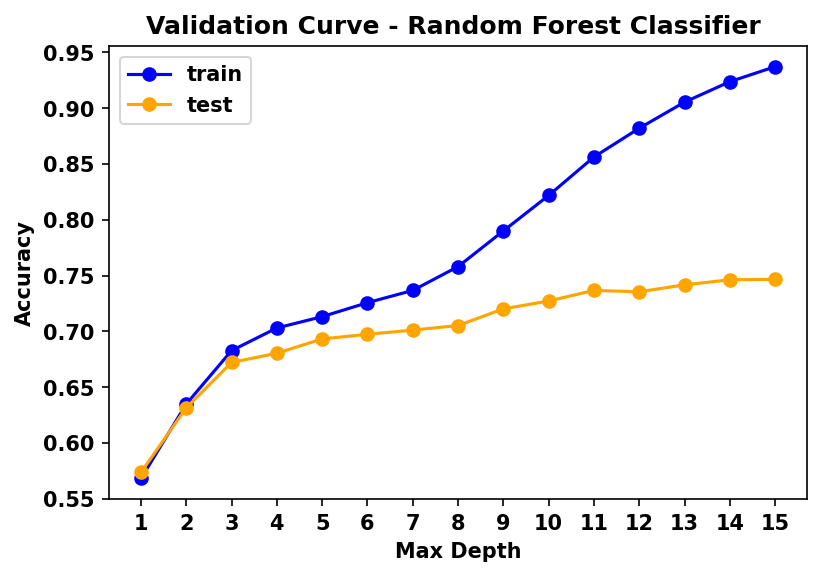

```python
f, ax = plt.subplots(dpi=150)
plt.plot(accuracy_train, marker='o', color='blue', label = 'train')
plt.plot(accuracy_test, marker='o',color='orange', label = 'test')
plt.title('Validation Curve - Random Forest Classifier ')
plt.xticks(ticks=np.arange(len(md_list)), labels=md_list, rotation=0)
plt.xlabel('Max Depth')
plt.ylabel('Accuracy')
plt.legend()
plt.show()
```

We can see from the chart that we reach optimum point in bias-variance tradeoff at about max_depth of 9 after this we do not see much impovement in test accuracy but training accuracy keep going up, we start moving towards overfitting zone.

```python
rf3=RandomForestClassifier(max_depth=9,min_samples_split=5, n_estimators=90)
rf3.fit(X_train2,y_train2)
pred = rf3.predict(X_train2)
rfTr2=metrics.accuracy_score(y_true = y_train2, y_pred = pred)
print(rfTr2)
```

```
0.7878505640070371
```

```python
pred = rf3.predict(X_test2)
rfTe2=metrics.accuracy_score(y_true = y_test2, y_pred = pred)
print(rfTe2)
```

```
0.7193708609271523
```

```python
print(metrics.classification_report(y_test2, pred))
```

```
              precision    recall  f1-score   support

           0       0.73      0.54      0.62      1030
           1       0.71      0.85      0.78      1386

    accuracy                           0.72      2416
   macro avg       0.72      0.70      0.70      2416
weighted avg       0.72      0.72      0.71      2416
```

```python
rfBa2=metrics.balanced_accuracy_score(y_test2,pred)
print(rfBa2)
```

```
0.6968085851580997
```

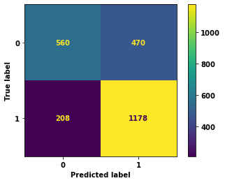

```python
plot_confusion_matrix(rf3,X_test2,y_test2)
plt.show()
```

Since this model is not overfitting like the previous one, we can take a look at the feature importances

```python
[print(i) for i in zip(X_train2.columns, rf3.feature_importances_)];
```

```
('temperature', 0.04832610979763598)
('time', 0.08523680183578246)
('age', 0.05363330129871457)
('has_children', 0.023450372997371606)
('education', 0.04420339307995064)
('income', 0.05747888842755921)
('Bar', 0.07338780560868628)
('CoffeeHouse', 0.11262499363806099)
('CarryAway', 0.03736085202013654)
('RestaurantLessThan20', 0.03562388497879805)
('Restaurant20To50', 0.04131197905963058)
('toCoupon_GEQ15min', 0.03230977826774116)
('coupon_Bar', 0.059419432826845135)
('coupon_Carry out & Take away', 0.08456868731853762)
('coupon_Coffee House', 0.042645229692679074)
('coupon_Restaurant(<20)', 0.07386667125564032)
('expiration_2h', 0.07394472410744783)
('gender_Male', 0.0206070937887818)
```

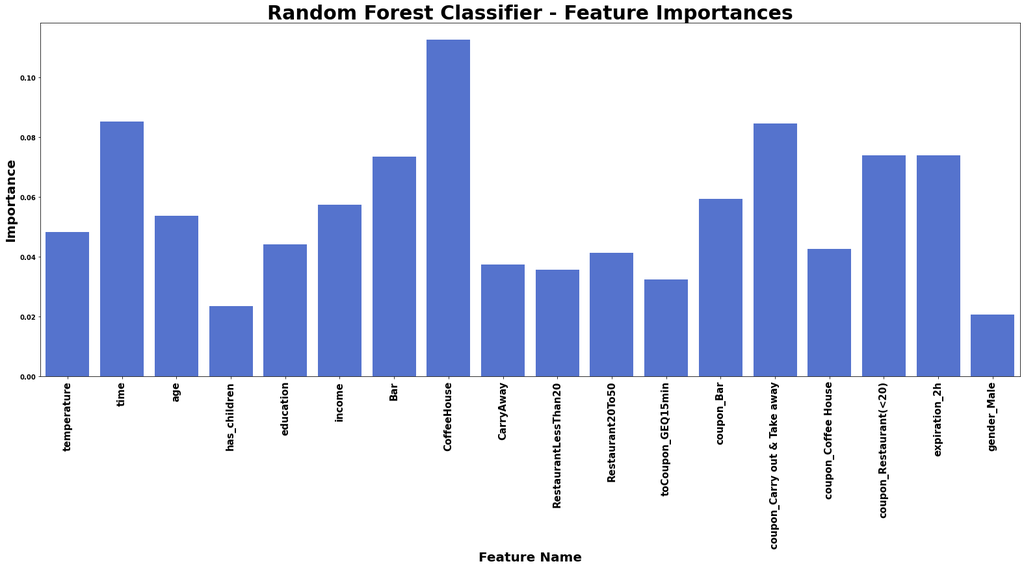

```python
plt.figure(figsize=[27,10])
importance = rf3.feature_importances_
feature_name = X_train2.columns
sns.barplot(x = feature_name, y = importance,color="royalblue")
plt.xticks(rotation = 90, fontsize=15)
plt.title('Random Forest Classifier - Feature Importances', fontsize=30)
plt.ylabel('Importance',fontsize=20)
plt.xlabel('Feature Name', fontsize=20)
plt.show()
```

```python
sorted(zip(rf3.feature_importances_, feature_name), reverse=True)
```

```
[(0.11262499363806099, 'CoffeeHouse'),
 (0.08523680183578246, 'time'),
 (0.08456868731853762, 'coupon_Carry out & Take away'),
 (0.07394472410744783, 'expiration_2h'),
 (0.07386667125564032, 'coupon_Restaurant(<20)'),
 (0.07338780560868628, 'Bar'),
 (0.059419432826845135, 'coupon_Bar'),
 (0.05747888842755921, 'income'),
 (0.05363330129871457, 'age'),
 (0.04832610979763598, 'temperature'),
 (0.04420339307995064, 'education'),
 (0.042645229692679074, 'coupon_Coffee House'),
 (0.04131197905963058, 'Restaurant20To50'),
 (0.03736085202013654, 'CarryAway'),
 (0.03562388497879805, 'RestaurantLessThan20'),
 (0.03230977826774116, 'toCoupon_GEQ15min'),
 (0.023450372997371606, 'has_children'),
 (0.0206070937887818, 'gender_Male')]
```

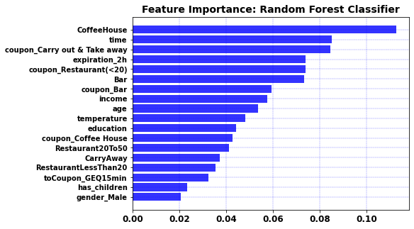

```python
model_type = 'rf3'
model_dict = {'rf3':rf3.feature_importances_}
importances = model_dict[model_type]
indices = list(np.argsort(importances))
feature_names=X_train2.columns
names = [ feature_names[i] for i in indices]

fig,ax = plt.subplots(nrows=1,ncols=1,figsize=[7,5])
ax.barh(names, importances[indices], color = 'blue', align ='center',alpha=0.8)

xticklabel_rotation = 0
plt.xticks(rotation=xticklabel_rotation,fontsize=12)

plt.yticks(fontsize=10)
ax.grid(color='b', ls = '-.', lw = 0.25)

# Title
ax.set_title("Feature Importance: Random Forest Classifier",fontsize=14)

# Show plot
plt.show()
```

```python
tn, fp, fn, tp = metrics.confusion_matrix(y_test2, pred).ravel()
recall_score = metrics.recall_score(y_test2, pred)
specificity = tn / (tn+fp)
precision_score = metrics.precision_score(y_test2, pred)
accuracy = metrics.accuracy_score(y_test2, pred)
balanced_accuracy = metrics.balanced_accuracy_score(y_test2, pred)
f1_score = metrics.f1_score(y_test2, pred)
fpr = fp / (fp + tn)
print("\nMetrics on test data")
print('Recall Score :', round(recall_score,2))
print('Specificity :', round(specificity,2))
print('Precision Score :', round(precision_score,2))
print('Accuracy:', round(accuracy,2))
print('Balanced Accuracy:', round(balanced_accuracy,2))
print('F1 Score :', round(f1_score,2))
```

```
Metrics on test data
Recall Score : 0.85
Specificity : 0.54
Precision Score : 0.71
Accuracy: 0.72
Balanced Accuracy: 0.7
F1 Score : 0.78
```

### Logistic Regression on RF Reduced Dataset

The next classifier that was tested was logistic regression. Again, grid search was used to find the most optimal parameters.

```python
lr=LogisticRegression(solver='liblinear')
params=dict(
    penalty=['l1','l2'],
    C=[0.001, 0.01, 0.1, 1, 10, 100],
    class_weight=[None, 'balanced']
)
gs = GridSearchCV(estimator=lr, param_grid=params, cv=cv, n_jobs=-1, )
gs
gs.fit(X_train2, y_train2)
gs.best_params_
```

```
{'C': 0.1, 'class_weight': None, 'penalty': 'l2'}
```

Grid search found the most optimal parameters to be C: 0.1, class_weight: None, penalty: L2.

```python
lr=LogisticRegression(C=0.1)
lr.fit(X_train2,y_train2)
pred = lr.predict(X_train2)
lrTr = metrics.accuracy_score(y_true = y_train2, y_pred = pred)
print(lrTr)
```

```
0.6719445306840526
```

```python
pred = lr.predict(X_test2)
lrTe = metrics.accuracy_score(y_true = y_test2, y_pred = pred)
print(lrTe)
```

```
0.6432119205298014
```

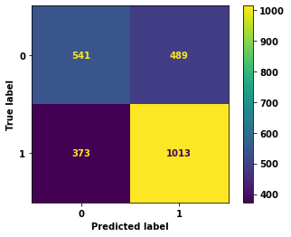

```python
plot_confusion_matrix(lr,X_test2,y_test2)
plt.show()
```

```python
print(metrics.classification_report(y_test2, pred))
```

```
              precision    recall  f1-score   support

           0       0.59      0.53      0.56      1030
           1       0.67      0.73      0.70      1386

    accuracy                           0.64      2416
   macro avg       0.63      0.63      0.63      2416
weighted avg       0.64      0.64      0.64      2416
```

```python
lrBa = metrics.balanced_accuracy_score(y_test2,pred)
print(lrBa)
```

```
0.6280614746634164
```

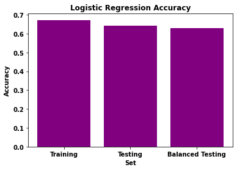

```python
import matplotlib.pyplot as plt
labels=['Training', 'Testing', 'Balanced Testing']
accs=[lrTr, lrTe, lrBa]
plt.bar(labels,accs,color='purple')
plt.ylabel('Accuracy')
plt.xlabel('Set')
plt.title('Logistic Regression Accuracy')
plt.show()
```

### Decision Trees on RF Reduced Dataset

The next classifier that was built was decision trees. This is similar to random forests in the idea that random forests is an ensemble method that considers many decision trees, but is worthwhile to test either way.

```python
dt=DecisionTreeClassifier()
params=dict(
    min_samples_split = [5, 10, 50, 100],
    max_depth = [1, 2, 3, 4, 5, 7, 10, None],
    criterion=['entropy','gini']
)
gs = GridSearchCV(estimator=dt, param_grid=params, cv=cv, n_jobs=-1, )
gs
gs.fit(X_train2, y_train2)
gs.best_params_
```

```
{'criterion': 'entropy', 'max_depth': None, 'min_samples_split': 100}
```

The best parameters based on grid search were found to be criterion: entropy, max_depth: None, and min_samples_split: 100.

```python
dt=DecisionTreeClassifier(criterion='entropy',min_samples_split=100)
dt.fit(X_train2,y_train2)
pred = dt.predict(X_train2)
dfTr=metrics.accuracy_score(y_true = y_train2, y_pred = pred)
print(dfTr)
```

```
0.7461450895167132
```

```python
pred = dt.predict(X_test2)
dfTe=metrics.accuracy_score(y_true = y_test2, y_pred = pred)
print(dfTe)
```

```
0.7036423841059603
```

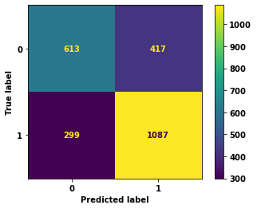

```python
plot_confusion_matrix(dt,X_test2,y_test2)
plt.show()
```

```python
print(metrics.classification_report(y_test2, pred))
```

```
              precision    recall  f1-score   support

           0       0.67      0.60      0.63      1030
           1       0.72      0.78      0.75      1386

    accuracy                           0.70      2416
   macro avg       0.70      0.69      0.69      2416
weighted avg       0.70      0.70      0.70      2416
```

```python
dfBa=metrics.balanced_accuracy_score(y_test2,pred)
print(dfBa)
```

```
0.6897084576696226
```

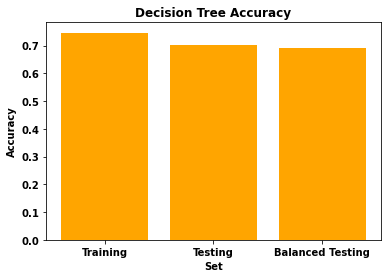

```python
labels=['Training', 'Testing', 'Balanced Testing']
accs=[dfTr, dfTe, dfBa]
plt.bar(labels,accs,color='orange')
plt.ylabel('Accuracy')
plt.xlabel('Set')
plt.title('Decision Tree Accuracy')
plt.show()
```

### Decision Trees Max Depth Limit on RF Reduced Dataset

```python
# Code here
md_list = [1,2,3,4,5,6,7,8,9,10,11,12,13,14,15,20]
accuracy_train = []
accuracy_test = []
for md in md_list:
    dtclf=DecisionTreeClassifier(criterion='entropy',min_samples_split=100,max_depth=md)
    # Code here
    dtclf.fit(X_train2, y_train2)

    pred=dtclf.predict(X_train2)
    accuracy_train.append(metrics.accuracy_score(y_train2, pred))

    pred=dtclf.predict(X_test2)
    accuracy_test.append(metrics.accuracy_score(y_test2, pred))
```

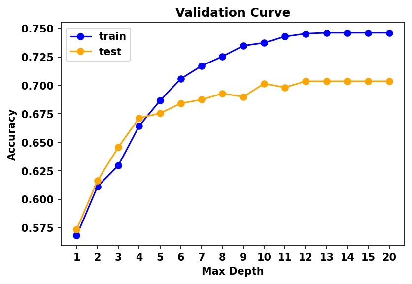

```python
f, ax = plt.subplots(dpi=150)
plt.plot(accuracy_train, marker='o', color='blue', label = 'train')
plt.plot(accuracy_test, marker='o',color='orange', label = 'test')
plt.title('Validation Curve')
plt.xticks(ticks=np.arange(len(md_list)), labels=md_list, rotation=0)
plt.xlabel('Max Depth')
plt.ylabel('Accuracy')
plt.legend()
plt.show()
```

We can see from the chart that both training and testing accuracy goes up as we increase max_depth, and stabilize after max_depth of about 12. We are not seeing an overfitting trend here, but after around max_depth of 6, we don't see much increase in test accuracy. For the understanding/visualizing tree better, we will prune the tree with a max_depth of 6.

```python
dtclf=DecisionTreeClassifier(criterion='entropy',min_samples_split=100,max_depth=6)
dtclf.fit(X_train2,y_train2)
pred = dtclf.predict(X_train2)
metrics.accuracy_score(y_true = y_train2, y_pred = pred)
```

```
0.705784952913174
```

```python
pred = dtclf.predict(X_test2)
metrics.accuracy_score(y_true = y_test2, y_pred = pred)
```

```
0.6841887417218543
```

```python
[print(i) for i in zip(X_train2.columns, dtclf.feature_importances_)];
```

```
('temperature', 0.04650503552365416)
('time', 0.09551591564439264)
('age', 0.005383922384804513)
('has_children', 0.019410152123863367)
('education', 0.0)
('income', 0.02765013282496129)
('Bar', 0.08786237186904788)
('CoffeeHouse', 0.14167221737927008)
('CarryAway', 0.008838275272991645)
('RestaurantLessThan20', 0.008150643772490513)
('Restaurant20To50', 0.010307156707656612)
('toCoupon_GEQ15min', 0.01462593195755462)
('coupon_Bar', 0.009766524102508521)
('coupon_Carry out & Take away', 0.1204634672734796)
('coupon_Coffee House', 0.08123982326458727)
('coupon_Restaurant(<20)', 0.17298895945248544)
('expiration_2h', 0.14961947044625193)
('gender_Male', 0.0)
```

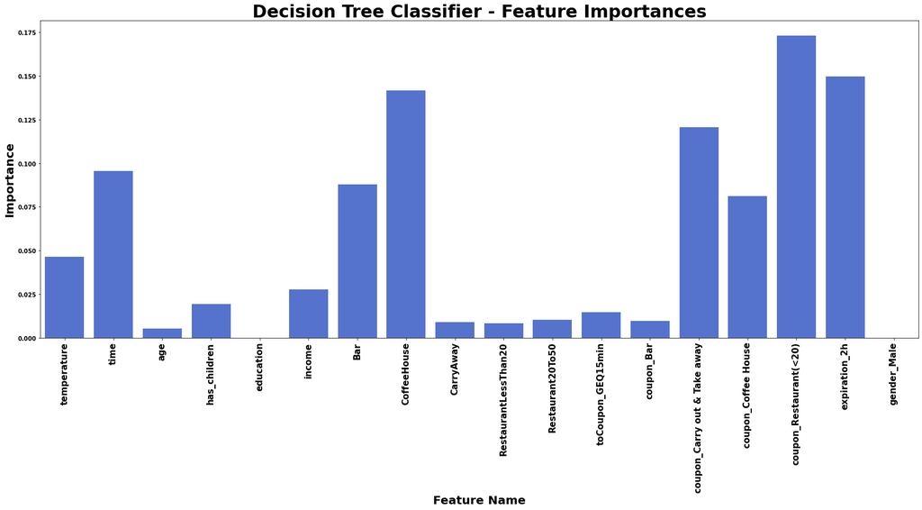

```python
plt.figure(figsize=[27,10])
importance = dtclf.feature_importances_
feature_name = X_train2.columns
sns.barplot(x = feature_name, y = importance,color="royalblue")
plt.xticks(rotation = 90, fontsize = 15)
plt.title('Decision Tree Classifier - Feature Importances', fontsize=30)
plt.ylabel('Importance',fontsize=20)
plt.xlabel('Feature Name', fontsize=20)
plt.show()
```

```python
sorted(zip(dtclf.feature_importances_, feature_name), reverse=True)
```

```
[(0.17298895945248544, 'coupon_Restaurant(<20)'),
 (0.14961947044625193, 'expiration_2h'),
 (0.14167221737927008, 'CoffeeHouse'),
 (0.1204634672734796, 'coupon_Carry out & Take away'),
 (0.09551591564439264, 'time'),
 (0.08786237186904788, 'Bar'),
 (0.08123982326458727, 'coupon_Coffee House'),
 (0.04650503552365416, 'temperature'),
 (0.02765013282496129, 'income'),
 (0.019410152123863367, 'has_children'),
 (0.01462593195755462, 'toCoupon_GEQ15min'),
 (0.010307156707656612, 'Restaurant20To50'),
 (0.009766524102508521, 'coupon_Bar'),
 (0.008838275272991645, 'CarryAway'),
 (0.008150643772490513, 'RestaurantLessThan20'),
 (0.005383922384804513, 'age'),
 (0.0, 'gender_Male'),
 (0.0, 'education')]
```

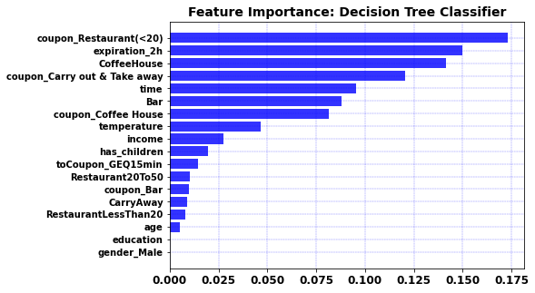

```python
model_type = 'dtclf'
model_dict = {'dtclf':dtclf.feature_importances_}
importances = model_dict[model_type]
indices = list(np.argsort(importances))
feature_names=X_train2.columns
names = [ feature_names[i] for i in indices]

fig,ax = plt.subplots(nrows=1,ncols=1,figsize=[7,5])
ax.barh(names, importances[indices], color = 'blue', align ='center',alpha=0.8)

xticklabel_rotation = 0
plt.xticks(rotation=xticklabel_rotation,fontsize=12)

plt.yticks(fontsize=10)
ax.grid(color='b', ls = '-.', lw = 0.25)

# Title
ax.set_title("Feature Importance: Decision Tree Classifier",fontsize=14)

# Show plot
plt.show()
```

```python
print(metrics.classification_report(y_test2, pred))
```

```
              precision    recall  f1-score   support

           0       0.65      0.56      0.60      1030
           1       0.70      0.78      0.74      1386

    accuracy                           0.68      2416
   macro avg       0.68      0.67      0.67      2416
weighted avg       0.68      0.68      0.68      2416
```

```python
print(metrics.balanced_accuracy_score(y_test2,pred))
```

```
0.6683891620784825
```

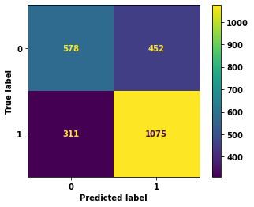

```python
plot_confusion_matrix(dtclf,X_test2,y_test2)
plt.show()
```

```python
tn, fp, fn, tp = metrics.confusion_matrix(y_test2, pred).ravel()
recall_score = metrics.recall_score(y_test2, pred)
specificity = tn / (tn+fp)
precision_score = metrics.precision_score(y_test2, pred)
accuracy = metrics.accuracy_score(y_test2, pred)
balanced_accuracy = metrics.balanced_accuracy_score(y_test2, pred)
f1_score = metrics.f1_score(y_test2, pred)
fpr = fp / (fp + tn)
print("\nMetrics on test data")
print('Recall Score :', round(recall_score,2))
print('Specificity :', round(specificity,2))
print('Precision Score :', round(precision_score,2))
print('Accuracy:', round(accuracy,2))
print('Balanced Accuracy:', round(balanced_accuracy,2))
print('F1 Score :', round(f1_score,2))
```

```
Metrics on test data
Recall Score : 0.78
Specificity : 0.56
Precision Score : 0.7
Accuracy: 0.68
Balanced Accuracy: 0.67
F1 Score : 0.74
```

```python
from sklearn.tree import export_graphviz
export_graphviz(dtclf,out_file='tree.dot', feature_names=X_train2.columns)
```

```python
import graphviz

with open("tree.dot") as f:
    dot_graph = f.read()
graphviz.Source(dot_graph)
```

[figure not shown]

```python
export_graphviz(dtclf,out_file='tree.dot', feature_names=X_train2.columns, class_names=["No","Yes"], filled=True)

with open("tree.dot") as f:
    dot_graph = f.read()
graphviz.Source(dot_graph)
```

[figure not shown]

```python
system(dot -Tpng tree.dot -o dtree.png)
```

```
[]
```

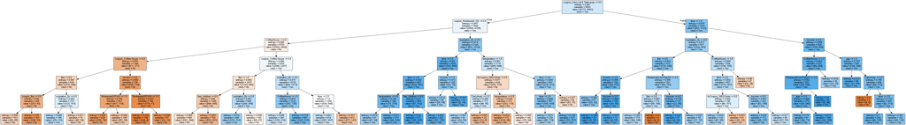

```python
from IPython.display import Image
Image(filename='dtree.png', width=1200, height = 1000)
```

If we look at the decision tree root node is "coupon_Carry out & Take away" tree is then further split on "coupon_Resturant(<20), time, coffeehouse and income respectively.